# Out-of-sample validation of mixed-model RESI: Tennessee STAR

`mlmRev::star` hybrid plasmode: point-estimate calibration and CI coverage

2026-11-16

# 1 Purpose

The mixed-model RESI point estimator, its Lyu–Welsh targets and the confidence intervals of `notes/resi_mixed_ci.qmd` were developed and checked on `mlmRev::egsingle`. This report repeats the same hybrid plasmode on a dataset they were **not** developed on, to check that nothing in the methods or the simulation framework is tuned to egsingle. The code is shared: `hybridPlasmodeSim()`, `lyuLimitResi()`, `expectedDesignResi()`, `designAveragedSe()` and `resi()` in the package, and `tests/mixed_ci_coverage_lib.R` for the coverage summaries. Only the data preparation (`tests/star_data.R`) and the driver (`tests/run_star_validation.R`) are new.

# 2 Dataset and model

`mlmRev::star` is the Tennessee STAR class-size experiment: yearly mathematics scores (kindergarten to grade 3) for students nested in schools, the same occasion < student < school nesting as egsingle but with far fewer occasions per student and different kinds of covariates.

Complete cases on the model variables

| Quantity | Value |
| --- | --- |
| schools | 80 |
| students | 11009 |
| measurements | 23982 |
| students per school (min / median / max) | 54 / 126 / 362 |
| measurements per student (mean) | 2.18 |

Model (fitted by ML to the full data; the fit is the data-generating truth):

math ~ yrs + sx + black + ses + cltype + schtype3 + fl_10 + (1 | sch/sid)

- `yrs`: years in the study (0–3), varies within student.
- `cltype`: class type (small / regular / regular with aide; reference regular), assigned by the experiment and varying within student; a 2-df within-school term.
- `ses`: free-lunch status (reference not free lunch), varies within student.
- `sx`, `black`: student-level.
- `schtype3`: school type (city = inner-city + urban, suburb, rural); a 2-df **between-school** factor, which egsingle does not have.
- `fl_10`: school percentage of free-lunch measurements in units of 10 points; a continuous between-school term.

Rare categories were merged so that resampled designs rarely lose a factor level (only 7 of 80 schools are urban; about 65 students are neither white nor black). Replicates that still lose a level are counted as failed fits; the student id is made unique within school because 446 students appear in more than one school.

Variance components of the full-data ML fit

| component | variance | proportion |
| --- | --- | --- |
| sid:sch | 904.038 | 0.522 |
| sch | 116.790 | 0.067 |
| Residual | 712.133 | 0.411 |

Coefficient RESI targets: Lyu-Welsh limit, fixed-m expected-design value at m = 25 and 200, and the full-data estimate, with the variance proportions of each covariate

| term | level | S_Lyu | S_m25 | S_m200 | full_data | Var prop sch | Var prop sid:sch |
| --- | --- | --- | --- | --- | --- | --- | --- |
| (Intercept) | sch | 10.619 | 8.449 | 10.245 | 10.089 |  |  |
| yrs | sid:sch | 2.252 | 2.261 | 2.254 | 2.254 | 0.040 | 0.366 |
| sxF | sid:sch | 0.042 | 0.042 | 0.042 | 0.042 | 0.010 | 0.990 |
| black1 | sid:sch | -0.122 | -0.133 | -0.124 | -0.125 | 0.723 | 0.277 |
| sesF | sid:sch | -0.171 | -0.171 | -0.171 | -0.171 | 0.284 | 0.592 |
| cltypesmall | sid:sch | 0.088 | 0.089 | 0.088 | 0.088 | 0.017 | 0.889 |
| cltypereg+A | sid:sch | 0.016 | 0.016 | 0.016 | 0.016 | 0.023 | 0.759 |
| schtype3suburb | sch | 0.036 | 0.029 | 0.035 | 0.034 | 1.000 | 0.000 |
| schtype3rural | sch | 0.057 | 0.045 | 0.055 | 0.054 | 1.000 | 0.000 |
| fl_10 | sch | -0.062 | -0.047 | -0.059 | -0.058 | 1.000 | 0.000 |

ANOVA-term RESI targets

| term | df | level | S_Lyu | S_m25 | S_m200 | full_data |
| --- | --- | --- | --- | --- | --- | --- |
| yrs | 1 | sid:sch | 2.252 | 2.261 | 2.254 | 2.254 |
| sx | 1 | sid:sch | 0.042 | 0.042 | 0.042 | 0.041 |
| black | 1 | sid:sch | 0.122 | 0.133 | 0.124 | 0.125 |
| ses | 1 | sid:sch | 0.171 | 0.171 | 0.171 | 0.171 |
| cltype | 2 | sid:sch | 0.091 | 0.091 | 0.091 | 0.090 |
| schtype3 | 2 | sch | 0.058 | 0.046 | 0.055 | 0.000 |
| fl_10 | 1 | sch | 0.062 | 0.047 | 0.059 | 0.000 |

Apart from `yrs`, every effect is small, and the between-school effects (`schtype3`, `fl_10`) are near zero. This tests the intervals in the near-null regime, which is rarer in egsingle.

# 3 Point-estimate calibration

`hybridPlasmodeSim()` with `n_schools` $\in \{15, 30, 60, 100\}$ × `n_per_site` $\in \{25, 100, 200\}$, 1000 replicates per cell (seed 2026). The figure has the same layout as the egsingle report.

Successful replicates (of 1000) per cell

| n_schools | n_success.25 | n_success.100 | n_success.200 |
| --- | --- | --- | --- |
| 15 | 968 | 972 | 967 |
| 30 | 1000 | 998 | 998 |
| 60 | 1000 | 1000 | 1000 |
| 100 | 1000 | 1000 | 1000 |

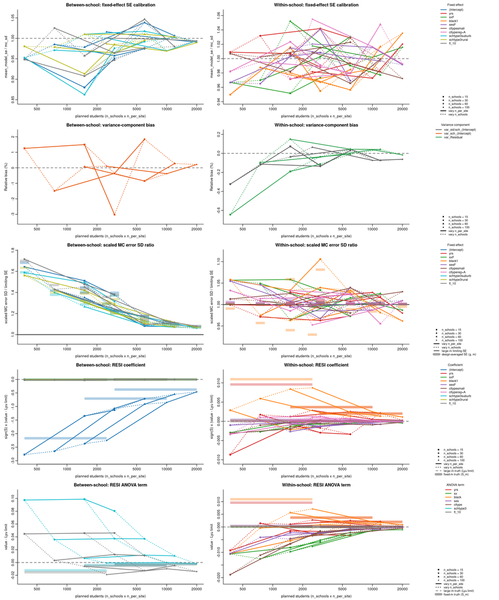

Fixed effects: model SE / MC SD, and scaled MC error SD and design-averaged SE relative to the Lyu limiting per-unit SE

| n_schools | n_per_site | term | se_ratio | scaled_mc_error_sd_ratio | se_ratio_design_avg |
| --- | --- | --- | --- | --- | --- |
| 15 | 25 | (Intercept) | 0.951 | 1.643 | 1.681 |
| 15 | 100 | (Intercept) | 0.880 | 1.511 | 1.448 |
| 15 | 200 | (Intercept) | 0.951 | 1.374 | 1.397 |
| 30 | 25 | (Intercept) | 0.985 | 1.428 | 1.418 |
| 30 | 100 | (Intercept) | 0.957 | 1.227 | 1.222 |
| 30 | 200 | (Intercept) | 0.975 | 1.166 | 1.180 |
| 60 | 25 | (Intercept) | 0.978 | 1.351 | 1.329 |
| 60 | 100 | (Intercept) | 1.038 | 1.080 | 1.129 |
| 60 | 200 | (Intercept) | 1.006 | 1.075 | 1.098 |
| 100 | 25 | (Intercept) | 1.016 | 1.266 | 1.292 |
| 100 | 100 | (Intercept) | 0.998 | 1.105 | 1.105 |
| 100 | 200 | (Intercept) | 0.991 | 1.071 | 1.076 |
| 15 | 25 | black1 | 0.950 | 1.058 | 0.991 |
| 15 | 100 | black1 | 1.016 | 1.033 | 1.059 |
| 15 | 200 | black1 | 0.955 | 1.106 | 1.081 |
| 30 | 25 | black1 | 0.988 | 0.975 | 0.957 |
| 30 | 100 | black1 | 0.967 | 1.039 | 1.010 |
| 30 | 200 | black1 | 0.985 | 1.027 | 1.032 |
| 60 | 25 | black1 | 0.980 | 0.963 | 0.940 |
| 60 | 100 | black1 | 0.956 | 1.033 | 0.989 |
| 60 | 200 | black1 | 1.017 | 0.981 | 1.008 |
| 100 | 25 | black1 | 0.970 | 0.964 | 0.930 |
| 100 | 100 | black1 | 0.986 | 0.999 | 0.984 |
| 100 | 200 | black1 | 1.035 | 0.962 | 0.995 |
| 15 | 25 | cltypereg+A | 0.982 | 1.033 | 1.005 |
| 15 | 100 | cltypereg+A | 1.023 | 0.985 | 1.005 |
| 15 | 200 | cltypereg+A | 0.991 | 1.016 | 1.008 |
| 30 | 25 | cltypereg+A | 0.995 | 1.014 | 1.003 |
| 30 | 100 | cltypereg+A | 0.989 | 1.017 | 1.003 |
| 30 | 200 | cltypereg+A | 0.980 | 1.023 | 1.003 |

[output cut: 90 more lines]

RESI: targets and simulation mean and SD

| n_schools | n_per_site | table | term | S_Lyu | S_m | mc_mean_resi | mc_sd_resi |
| --- | --- | --- | --- | --- | --- | --- | --- |
| 15 | 25 | anova | black | 0.122 | 0.133 | 0.112 | 0.064 |
| 15 | 100 | anova | black | 0.122 | 0.126 | 0.117 | 0.035 |
| 15 | 200 | anova | black | 0.122 | 0.124 | 0.119 | 0.030 |
| 30 | 25 | anova | black | 0.122 | 0.133 | 0.122 | 0.044 |
| 30 | 100 | anova | black | 0.122 | 0.126 | 0.123 | 0.024 |
| 30 | 200 | anova | black | 0.122 | 0.124 | 0.123 | 0.020 |
| 60 | 25 | anova | black | 0.122 | 0.133 | 0.128 | 0.029 |
| 60 | 100 | anova | black | 0.122 | 0.126 | 0.124 | 0.017 |
| 60 | 200 | anova | black | 0.122 | 0.124 | 0.123 | 0.013 |
| 100 | 25 | anova | black | 0.122 | 0.133 | 0.129 | 0.022 |
| 100 | 100 | anova | black | 0.122 | 0.126 | 0.124 | 0.013 |
| 100 | 200 | anova | black | 0.122 | 0.124 | 0.123 | 0.011 |
| 15 | 25 | anova | cltype | 0.091 | 0.091 | 0.072 | 0.058 |
| 15 | 100 | anova | cltype | 0.091 | 0.091 | 0.084 | 0.030 |
| 15 | 200 | anova | cltype | 0.091 | 0.091 | 0.089 | 0.019 |
| 30 | 25 | anova | cltype | 0.091 | 0.091 | 0.079 | 0.043 |
| 30 | 100 | anova | cltype | 0.091 | 0.091 | 0.089 | 0.019 |
| 30 | 200 | anova | cltype | 0.091 | 0.091 | 0.089 | 0.013 |
| 60 | 25 | anova | cltype | 0.091 | 0.091 | 0.086 | 0.028 |
| 60 | 100 | anova | cltype | 0.091 | 0.091 | 0.090 | 0.014 |
| 60 | 200 | anova | cltype | 0.091 | 0.091 | 0.090 | 0.009 |
| 100 | 25 | anova | cltype | 0.091 | 0.091 | 0.087 | 0.021 |
| 100 | 100 | anova | cltype | 0.091 | 0.091 | 0.089 | 0.010 |
| 100 | 200 | anova | cltype | 0.091 | 0.091 | 0.090 | 0.007 |
| 15 | 25 | anova | fl_10 | 0.062 | 0.047 | 0.107 | 0.185 |
| 15 | 100 | anova | fl_10 | 0.062 | 0.057 | 0.108 | 0.192 |
| 15 | 200 | anova | fl_10 | 0.062 | 0.059 | 0.108 | 0.184 |
| 30 | 25 | anova | fl_10 | 0.062 | 0.047 | 0.065 | 0.113 |
| 30 | 100 | anova | fl_10 | 0.062 | 0.057 | 0.075 | 0.132 |
| 30 | 200 | anova | fl_10 | 0.062 | 0.059 | 0.073 | 0.130 |

[output cut: 174 more lines]

# 4 Confidence interval coverage

As for egsingle: `n_schools` $\in \{15, 100\}$ × `n_per_site` $\in \{25, 200\}$, 1000 replicates per cell (seed 2027), intervals from `resi()`’s internal `.resi_ci_mixed()` with the model-based and CR2 (school-clustered) covariances and the normal, QF and CF methods, scored against $S_m$ and $S_{\text{Lyu}}$. Grey band: $0.95 \pm 1.96$ Monte Carlo SE. Solid lines are between-school terms.

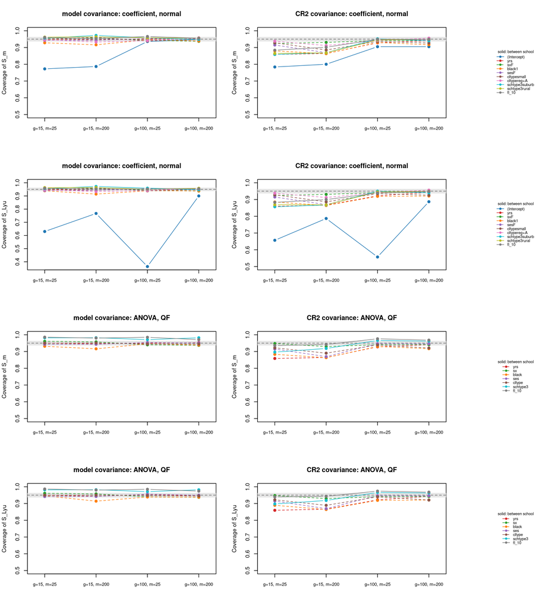

Coverage of S_m and S_Lyu by method (nominal 0.95; Monte Carlo SE 0.007)

| n_schools | n_per_site | table | term | covariance | coverage_S_m.normal | coverage_S_Lyu.normal | coverage_S_m.qf | coverage_S_Lyu.qf | coverage_S_m.cf | coverage_S_Lyu.cf |
| --- | --- | --- | --- | --- | --- | --- | --- | --- | --- | --- |
| 15 | 25 | anova | black | CR2 | 0.769 | 0.788 | 0.883 | 0.889 | 0.878 | 0.876 |
| 15 | 200 | anova | black | CR2 | 0.857 | 0.858 | 0.863 | 0.864 | 0.863 | 0.864 |
| 100 | 25 | anova | black | CR2 | 0.919 | 0.916 | 0.930 | 0.919 | 0.930 | 0.919 |
| 100 | 200 | anova | black | CR2 | 0.915 | 0.922 | 0.917 | 0.921 | 0.917 | 0.921 |
| 15 | 25 | anova | cltype | CR2 | 0.941 | 0.940 | 0.922 | 0.922 | 0.945 | 0.944 |
| 15 | 200 | anova | cltype | CR2 | 0.872 | 0.872 | 0.890 | 0.889 | 0.890 | 0.889 |
| 100 | 25 | anova | cltype | CR2 | 0.925 | 0.923 | 0.939 | 0.940 | 0.939 | 0.940 |
| 100 | 200 | anova | cltype | CR2 | 0.921 | 0.922 | 0.921 | 0.921 | 0.921 | 0.921 |
| 15 | 25 | anova | fl_10 | CR2 | 0.949 | 0.956 | 0.935 | 0.940 | 0.958 | 0.960 |
| 15 | 200 | anova | fl_10 | CR2 | 0.960 | 0.961 | 0.942 | 0.943 | 0.966 | 0.966 |
| 100 | 25 | anova | fl_10 | CR2 | 0.981 | 0.988 | 0.976 | 0.974 | 0.978 | 0.981 |
| 100 | 200 | anova | fl_10 | CR2 | 0.981 | 0.984 | 0.968 | 0.968 | 0.972 | 0.973 |
| 15 | 25 | anova | schtype3 | CR2 | 0.864 | 0.866 | 0.897 | 0.898 | 0.914 | 0.916 |
| 15 | 200 | anova | schtype3 | CR2 | 0.889 | 0.889 | 0.918 | 0.918 | 0.939 | 0.939 |
| 100 | 25 | anova | schtype3 | CR2 | 0.965 | 0.972 | 0.966 | 0.966 | 0.968 | 0.976 |
| 100 | 200 | anova | schtype3 | CR2 | 0.963 | 0.967 | 0.962 | 0.963 | 0.969 | 0.970 |
| 15 | 25 | anova | ses | CR2 | 0.862 | 0.863 | 0.915 | 0.915 | 0.915 | 0.916 |
| 15 | 200 | anova | ses | CR2 | 0.872 | 0.870 | 0.870 | 0.870 | 0.870 | 0.870 |
| 100 | 25 | anova | ses | CR2 | 0.942 | 0.942 | 0.947 | 0.947 | 0.947 | 0.947 |
| 100 | 200 | anova | ses | CR2 | 0.944 | 0.946 | 0.946 | 0.946 | 0.946 | 0.946 |
| 15 | 25 | anova | sx | CR2 | 0.969 | 0.969 | 0.948 | 0.948 | 0.957 | 0.957 |
| 15 | 200 | anova | sx | CR2 | 0.835 | 0.835 | 0.930 | 0.930 | 0.892 | 0.892 |
| 100 | 25 | anova | sx | CR2 | 0.815 | 0.815 | 0.941 | 0.941 | 0.883 | 0.883 |
| 100 | 200 | anova | sx | CR2 | 0.935 | 0.933 | 0.941 | 0.942 | 0.942 | 0.942 |
| 15 | 25 | anova | yrs | CR2 | 0.858 | 0.859 | 0.859 | 0.860 | 0.859 | 0.860 |
| 15 | 200 | anova | yrs | CR2 | 0.864 | 0.866 | 0.864 | 0.866 | 0.864 | 0.865 |
| 100 | 25 | anova | yrs | CR2 | 0.928 | 0.922 | 0.928 | 0.922 | 0.927 | 0.922 |
| 100 | 200 | anova | yrs | CR2 | 0.941 | 0.943 | 0.941 | 0.943 | 0.941 | 0.943 |
| 15 | 25 | anova | black | model | 0.823 | 0.841 | 0.931 | 0.947 | 0.907 | 0.904 |
| 15 | 200 | anova | black | model | 0.906 | 0.914 | 0.916 | 0.914 | 0.916 | 0.915 |

[output cut: 106 more lines]

Mean estimated SD of the coefficient RESI / Monte Carlo SD

| n_schools | n_per_site | term | ratio.model | ratio.CR2 |
| --- | --- | --- | --- | --- |
| 15 | 25 | (Intercept) | 0.796 | 0.697 |
| 15 | 25 | yrs | 0.996 | 0.732 |
| 15 | 25 | sxF | 1.002 | 0.925 |
| 15 | 25 | black1 | 0.951 | 0.729 |
| 15 | 25 | sesF | 0.955 | 0.860 |
| 15 | 25 | cltypesmall | 0.984 | 0.894 |
| 15 | 25 | cltypereg+A | 0.969 | 0.884 |
| 15 | 25 | schtype3suburb | 0.937 | 0.618 |
| 15 | 25 | schtype3rural | 0.933 | 0.660 |
| 15 | 25 | fl_10 | 0.963 | 0.707 |
| 100 | 25 | (Intercept) | 1.003 | 0.895 |
| 100 | 25 | yrs | 1.008 | 0.944 |
| 100 | 25 | sxF | 0.982 | 0.965 |
| 100 | 25 | black1 | 0.992 | 0.920 |
| 100 | 25 | sesF | 1.007 | 0.956 |
| 100 | 25 | cltypesmall | 0.975 | 0.943 |
| 100 | 25 | cltypereg+A | 0.956 | 0.946 |
| 100 | 25 | schtype3suburb | 1.030 | 0.978 |
| 100 | 25 | schtype3rural | 1.011 | 0.966 |
| 100 | 25 | fl_10 | 0.999 | 0.957 |
| 15 | 200 | (Intercept) | 0.857 | 0.724 |
| 15 | 200 | yrs | 1.006 | 0.717 |
| 15 | 200 | sxF | 1.005 | 0.899 |
| 15 | 200 | black1 | 0.934 | 0.716 |
| 15 | 200 | sesF | 1.001 | 0.761 |
| 15 | 200 | cltypesmall | 1.013 | 0.778 |
| 15 | 200 | cltypereg+A | 0.974 | 0.868 |
| 15 | 200 | schtype3suburb | 0.961 | 0.649 |
| 15 | 200 | schtype3rural | 0.973 | 0.703 |
| 15 | 200 | fl_10 | 0.967 | 0.708 |
| 100 | 200 | (Intercept) | 1.047 | 0.887 |
| 100 | 200 | yrs | 0.996 | 0.996 |
| 100 | 200 | sxF | 0.961 | 0.956 |
| 100 | 200 | black1 | 0.985 | 0.906 |
| 100 | 200 | sesF | 1.011 | 0.991 |
| 100 | 200 | cltypesmall | 0.980 | 0.936 |
| 100 | 200 | cltypereg+A | 1.029 | 1.020 |
| 100 | 200 | schtype3suburb | 1.020 | 0.951 |
| 100 | 200 | schtype3rural | 1.010 | 0.960 |
| 100 | 200 | fl_10 | 0.999 | 0.951 |

Mean and minimum coverage over terms

| covariance | method | table | n_schools | n_per_site | coverage_S_m.mean | coverage_S_m.min | coverage_S_Lyu.mean | coverage_S_Lyu.min |
| --- | --- | --- | --- | --- | --- | --- | --- | --- |
| CR2 | cf | anova | 15 | 25 | 0.918 | 0.859 | 0.918 | 0.860 |
| CR2 | cf | anova | 15 | 200 | 0.898 | 0.863 | 0.898 | 0.864 |
| CR2 | cf | anova | 100 | 25 | 0.939 | 0.883 | 0.938 | 0.883 |
| CR2 | cf | anova | 100 | 200 | 0.944 | 0.917 | 0.945 | 0.921 |
| CR2 | normal | anova | 15 | 25 | 0.887 | 0.769 | 0.891 | 0.788 |
| CR2 | normal | anova | 15 | 200 | 0.878 | 0.835 | 0.879 | 0.835 |
| CR2 | normal | anova | 100 | 25 | 0.925 | 0.815 | 0.925 | 0.815 |
| CR2 | normal | anova | 100 | 200 | 0.943 | 0.915 | 0.945 | 0.922 |
| CR2 | qf | anova | 15 | 25 | 0.908 | 0.859 | 0.910 | 0.860 |
| CR2 | qf | anova | 15 | 200 | 0.897 | 0.863 | 0.897 | 0.864 |
| CR2 | qf | anova | 100 | 25 | 0.947 | 0.928 | 0.944 | 0.919 |
| CR2 | qf | anova | 100 | 200 | 0.942 | 0.917 | 0.943 | 0.921 |
| model | cf | anova | 15 | 25 | 0.958 | 0.907 | 0.958 | 0.904 |
| model | cf | anova | 15 | 200 | 0.949 | 0.916 | 0.948 | 0.915 |
| model | cf | anova | 100 | 25 | 0.949 | 0.883 | 0.950 | 0.883 |
| model | cf | anova | 100 | 200 | 0.955 | 0.937 | 0.954 | 0.937 |
| model | normal | anova | 15 | 25 | 0.936 | 0.823 | 0.940 | 0.841 |
| model | normal | anova | 15 | 200 | 0.932 | 0.841 | 0.933 | 0.842 |
| model | normal | anova | 100 | 25 | 0.935 | 0.809 | 0.938 | 0.809 |
| model | normal | anova | 100 | 200 | 0.955 | 0.928 | 0.954 | 0.928 |
| model | qf | anova | 15 | 25 | 0.957 | 0.931 | 0.960 | 0.942 |
| model | qf | anova | 15 | 200 | 0.954 | 0.916 | 0.953 | 0.914 |
| model | qf | anova | 100 | 25 | 0.956 | 0.940 | 0.956 | 0.939 |
| model | qf | anova | 100 | 200 | 0.954 | 0.937 | 0.953 | 0.937 |
| CR2 | cf | coefficients | 15 | 25 | 0.880 | 0.765 | 0.866 | 0.621 |
| CR2 | cf | coefficients | 15 | 200 | 0.874 | 0.778 | 0.873 | 0.761 |
| CR2 | cf | coefficients | 100 | 25 | 0.934 | 0.901 | 0.893 | 0.521 |
| CR2 | cf | coefficients | 100 | 200 | 0.934 | 0.897 | 0.933 | 0.874 |
| CR2 | normal | coefficients | 15 | 25 | 0.884 | 0.784 | 0.872 | 0.657 |
| CR2 | normal | coefficients | 15 | 200 | 0.876 | 0.800 | 0.875 | 0.787 |
| CR2 | normal | coefficients | 100 | 25 | 0.938 | 0.905 | 0.900 | 0.557 |
| CR2 | normal | coefficients | 100 | 200 | 0.937 | 0.905 | 0.936 | 0.887 |
| CR2 | qf | coefficients | 15 | 25 | 0.884 | 0.784 | 0.872 | 0.657 |
| CR2 | qf | coefficients | 15 | 200 | 0.876 | 0.800 | 0.875 | 0.787 |
| CR2 | qf | coefficients | 100 | 25 | 0.938 | 0.905 | 0.900 | 0.557 |
| CR2 | qf | coefficients | 100 | 200 | 0.937 | 0.905 | 0.936 | 0.887 |
| model | cf | coefficients | 15 | 25 | 0.932 | 0.769 | 0.916 | 0.607 |
| model | cf | coefficients | 15 | 200 | 0.930 | 0.780 | 0.929 | 0.757 |
| model | cf | coefficients | 100 | 25 | 0.949 | 0.932 | 0.887 | 0.328 |
| model | cf | coefficients | 100 | 200 | 0.949 | 0.935 | 0.943 | 0.892 |
| model | normal | coefficients | 15 | 25 | 0.932 | 0.773 | 0.918 | 0.630 |
| model | normal | coefficients | 15 | 200 | 0.933 | 0.787 | 0.931 | 0.767 |
| model | normal | coefficients | 100 | 25 | 0.949 | 0.936 | 0.890 | 0.364 |
| model | normal | coefficients | 100 | 200 | 0.949 | 0.937 | 0.943 | 0.900 |
| model | qf | coefficients | 15 | 25 | 0.932 | 0.773 | 0.918 | 0.630 |
| model | qf | coefficients | 15 | 200 | 0.933 | 0.787 | 0.931 | 0.767 |
| model | qf | coefficients | 100 | 25 | 0.949 | 0.936 | 0.890 | 0.364 |
| model | qf | coefficients | 100 | 200 | 0.949 | 0.937 | 0.943 | 0.900 |